# AdventuRes in Crafting a Data Science Career 🔮 + 💻 = 📊

Jasmine Dumas | [@jasdumas](https://twitter.com/jasdumas) | [jasdumas.github.io](http://jasdumas.github.io/)

Thursday, March 30th, 2017

# Hi Narragansett!

- I’m Jasmine Dumas
  - **Data Scientist** and **useR** living in Connecticut
  - Work at **Simple Finance** based in Portland, OR
  - Author of **`ttbbeer`** and **`shinyLP`**
- Slides and Materials available on GitHub:
  - [jasdumas/talks/rhodyrstats-R-user-group](https://github.com/jasdumas/talks/tree/master/rhodyrstats-R-user-group)

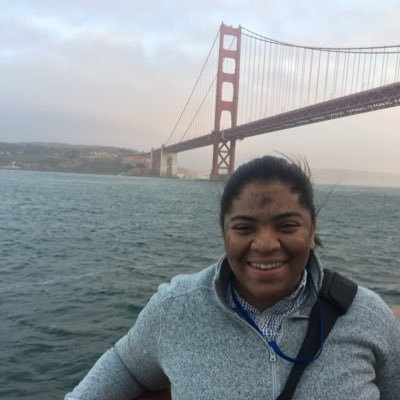

[figure not shown]

# I learned about data science from the internet

[figure not shown]

# [“A rose by any other name would smell as sweet”](https://en.wikipedia.org/wiki/A_rose_by_any_other_name_would_smell_as_sweet)

- Aside from the buzzword of “Data Science” and the *sought after title* “Data Scientist” people have been involved in this type of work under several different names:
  - Data Mining
  - Datalogy
  - Knowledge Discovery
  - Data Analytics
  - Business Analytics
  - Predictive Analytics
  - Machine Learning
  - Informatics
  - Applied Statistics
  - more? …

# Discovering resources can be a challenge

- With many types of resources and approaches available, the decision on *what* to learn and *who* to learn it from can be overwhelming given the lack of consensus in curriculum.
  - 🎓 Graduate/Undergraduate coursework
  - 🆓 Open source coursework
  - 👾 Massively open online coursework (MOOCs)
  - 🔩 Project experience
  - 🏕 Bootcamps
  - 💼 Job experience

[figure not shown]

# Dipping my toe in the water…

- Before enrolling in an **expensive** graduate school program, I wanted to gain some experience by combining MOOCs and project experience.
- Some considerations I had when selecting my data science curriculum:
  - low cost or free
  - reputable instructors
  - interactive platform
  - diverse programming approaches
  - applied projects for a portfolio

[figure not shown]

# Cold emailing does work!

- Have you ever wanted advice but didn’t know who to contact?
- Email someone in the field that you are interested in and ask about the path they took and what research they are engaged in!
- Tip on getting a response back: **Make it personal!**
  - I specifically emailed about advice on applying the graduate school and collaborating on a open source research project.

[figure not shown]

# The response…

```
## Time difference of 994 days
```

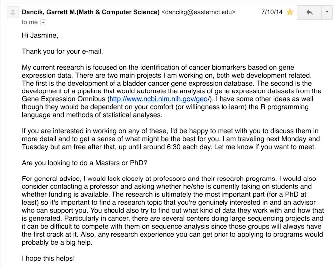

# My first exposure to R programming was through Shiny

- Shiny is a web application framework for R and is quite different from R syntactically
  - In 2014, shiny also did not have all of the features it has today
- Some of the usual R programming headaches came up like `stringsAsFactors = FALSE`
- It was a mixture of learning about Bioinformatics, gene expression data, bioconductor, and *designing a data product for a non-technical user*.
  - tl;dr: Gene expression data is not like the `iris` dataset

# Sometimes unpaid volunteer work does pays off…

- [Google Summer of Code](https://summerofcode.withgoogle.com/) is a global program for undergraduates and graduate students to get funding from **Google** to work on an open source project for the Summer!
- What it provides:
  - $5500.00
  - Opportunity to gain more programming skills
  - Interface with the R programming community
  - [Archival hosting](https://www.google-melange.com/archive/gsoc/2015/orgs/rproject/projects/jasdumas.html) of your abstract and code
  - Nobody talks about this heavily, but it does get you a *lifetime referral* for positions at Google!

# The result…

- A publication in [*Bioinformatics*](https://academic.oup.com/bioinformatics/article-abstract/32/23/3679/2525634/shinyGEO-a-web-based-application-for-analyzing)!

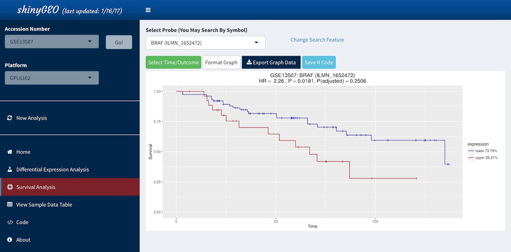

# How to make a connection to the R community

- ✅ Develop or contribute to packages (`ttbbeer`, `shinyGEO`)
- ✅ Answer (or ask for help) pleas for help on Twitter, through the [#rstats](https://twitter.com/hashtag/rstats?src=hash)
- ✅ Complete interesting analysis projects ([Web scraping and mapping breweries with import.io and R](https://trendct.org/2016/03/18/tutorial-web-scraping-and-mapping-breweries-with-import-io-and-r/))
- ✅ Start a podcast ([RTalk](https://itunes.apple.com/us/podcast/r-talk/id1030819337?mt=2))
- ✅ Start a blog ([jasdumas.github.io](https://jasdumas.github.io/))
- ✅ Put your code on GitHub (github.com/jasdumas)
- ✅ Attend conferences ([useR!](https://user2017.brussels/))
- ✅ Volunteer to review code/papers ([Mapping useRs](http://forwards.github.io/blog/2017/01/13/mapping-users/))
- ✅ Volunteer in community initiatives ([R-Ladies](http://rladies.org/), [Forwards](http://forwards.github.io/), [RWeekly](https://rweekly.org/))

# Applying for jobs that utilize R

- When searching for a Data Science Role, I look for:
  - Language agnostic (R, Python or SQL focus)
  - Job description (detailed and inclusive langauge)
  - Opportunities for advancement (transparency and organization)
  - Professional development (provide funding for conferences)
  - Diverse teams (experiences and backgrounds)
- It’s also a humbling experience to ask for help via twitter:

> Does anyone want to hire me to spice up their data with science using [#rstats](https://twitter.com/hashtag/rstats?src=hash)?  
> I'm looking for a job! 😬

> — Jasmine Dumas (@jasdumas) [March 24, 2016](https://twitter.com/jasdumas/status/713118293515759616)

# My path laid out

# Accessing beer statistics with `ttbbeer`

- An R data package of beer statistics from U.S. Department of the Treasury, Alcohol and Tobacco Tax and Trade Bureau (TTB)
  - available on [CRAN](https://cran.r-project.org/web/packages/ttbbeer/index.html) and [Github](https://github.com/jasdumas/ttbbeer)

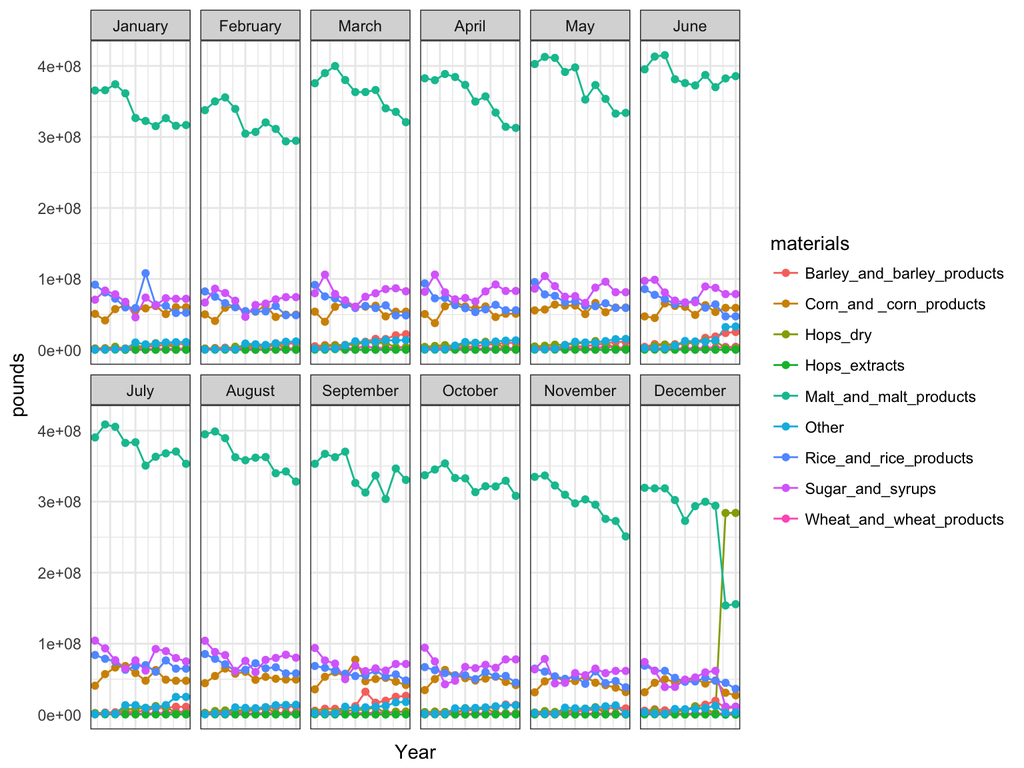

# Make landing pages for `shiny` apps with `shinyLP`

- Adds **even more Bootstrap** components to make landing home pages for Shiny
  - available on [CRAN](https://cran.r-project.org/web/packages/shinyLP/index.html) and [Github](https://github.com/jasdumas/shinyLP)

[figure not shown]

# Slide topics

1. intro to data science and how I discovered it
2. where i’m at now
   1. *`ttbbeer`
   2. `shinyLP`
3. how i got there
4. volunteering to collaborate on oss research
5. google summer of code
6. making a connection with the rstats community
7. documenting my path with technical writing
8. starting from the bottom (PT internships > FT Jr. DS position > Early career DS)
9. continuously volunteering for mentor ship and leadership roles in the rstats community